# Crab Foraging Trials Analysis - Averaged

## Per-crab data plotted

Now let’s look at the data plotted as number of mussels eaten *per crab* vs. number of mussels provided. Because the frair package doesn’t play nice with fractions, the data has been multiplied by 100, so units on the x and y axis are not accurate.

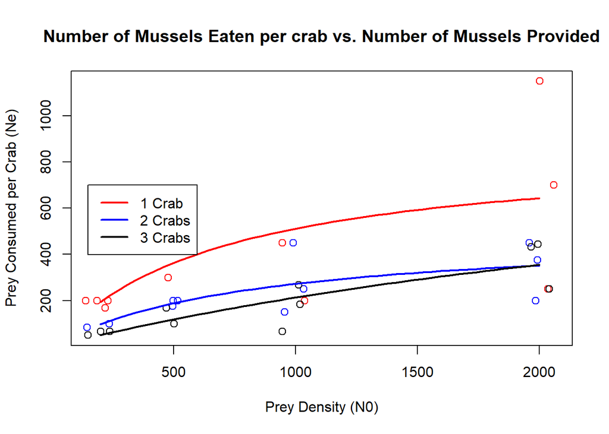

Below are the summarized FR response parameters on an individual and per crab basis. Note that the handling time was multiplied by 100 to account for the effect of multiplying the raw data. Attack rate was not affected by multiplication.

| density | analysis | a | st_err_a | h | st_err_h |
| --- | --- | --- | --- | --- | --- |
| 1 | grouped | 1.2475043 | NA | 0.1153037 | NA |
| 2 | grouped | 1.1472502 | NA | 0.0962016 | NA |
| 3 | grouped | 0.8696733 | 0.0200308 | 0.0391381 | 0.0000222 |
| 1 | per crab | 1.2475043 | NA | 0.1153037 | NA |
| 2 | per crab | 0.6082441 | 0.0320487 | 0.2022808 | 0.0000968 |
| 3 | per crab | 0.2668532 | 0.0148709 | 0.0941748 | 0.0001528 |

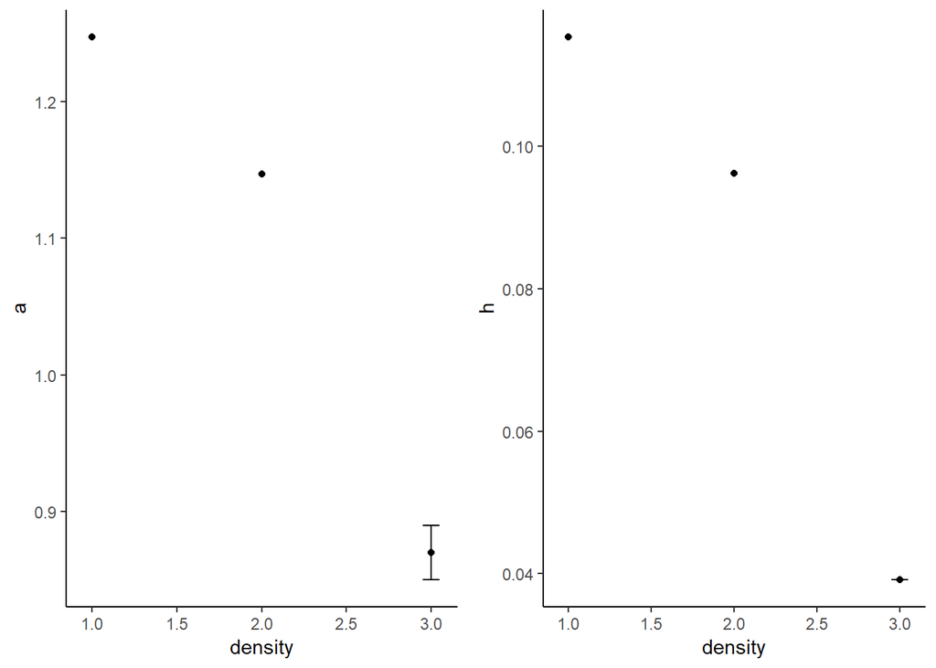

## Next steps

Next steps include

- Average the data points within each trial to avoid overconfidence in fits due to pseudoreplication
- Extract and statistically assess the differences in FR curve shapes provided by this analysis
- Figure out how to check for/account for any effect of size, which varied among trials
- Visualize confidence intervals for these fits and relationships